# 多因子模板之因子初选

陶阿明

2017/01/11

## 一、缺失值处理NA

多因子选股和单因子选股的不同在于因子之间的组合，无论是打分排序还是回归，首先都要对因子的缺失值进行处理。虽然可以利用中位数或者平均值等方法填充缺失值，但是当缺失值的确实比例达到一定程度，人为的填充缺失值，会破坏原有的因子分布特征，影响因子的有效性。

因而在进行后续研究之前，需要剔除缺失比例较高的因子。值得注意的是，在不同的样本空间内，因子的缺失比例也不同，举个最简单的例子，银行股预期因子基本没有缺失，但综合类行业的股票预期因子缺失比例较高。在**中证500**样本空间内，因子缺失比例如下表所示：

|  | Min. | X1st.Qu. | Median | Mean | X3rd.Qu. | Max. |
| --- | --- | --- | --- | --- | --- | --- |
| F_ROE_1 | 0.49 | 0.55 | 0.61 | 0.64 | 0.70 | 0.88 |
| F_PE_1_ | 0.49 | 0.55 | 0.61 | 0.64 | 0.70 | 0.88 |
| F_NP_chg_w13 | 0.49 | 0.55 | 0.61 | 0.64 | 0.70 | 0.88 |
| F_target_rtn_1_2 | 0.32 | 0.46 | 0.50 | 0.50 | 0.55 | 0.67 |
| F_rank_chg_60_1_2 | 0.14 | 0.18 | 0.21 | 0.24 | 0.25 | 0.49 |
| ILLIQ | 0.00 | 0.00 | 0.01 | 0.02 | 0.02 | 0.11 |
| IVR_ | 0.00 | 0.00 | 0.01 | 0.02 | 0.02 | 0.11 |
| liquidity_ | 0.00 | 0.00 | 0.01 | 0.02 | 0.02 | 0.11 |
| beta_ | 0.00 | 0.00 | 0.01 | 0.01 | 0.01 | 0.05 |
| disposition_ | 0.00 | 0.00 | 0.00 | 0.01 | 0.01 | 0.05 |
| GG_OR_Q_0 | 0.00 | 0.00 | 0.00 | 0.00 | 0.00 | 0.00 |
| GG_NP_Q_0 | 0.00 | 0.00 | 0.00 | 0.00 | 0.00 | 0.00 |
| G_MLL_Q | 0.00 | 0.00 | 0.00 | 0.00 | 0.00 | 0.00 |
| NP_YOY_0 | 0.00 | 0.00 | 0.00 | 0.00 | 0.00 | 0.00 |
| ln_mkt_cap_ | 0.00 | 0.00 | 0.00 | 0.00 | 0.00 | 0.00 |
| volatility_ | 0.00 | 0.00 | 0.00 | 0.00 | 0.00 | 0.00 |
| G_SCF_Q | 0.00 | 0.00 | 0.00 | 0.00 | 0.00 | 0.00 |
| pct_chg_per_60_ | 0.00 | 0.00 | 0.00 | 0.00 | 0.00 | 0.00 |
| PE_ttm_ | 0.00 | 0.00 | 0.00 | 0.00 | 0.00 | 0.00 |
| PB_mrq_ | 0.00 | 0.00 | 0.00 | 0.00 | 0.00 | 0.00 |

## 二、相关性处理Cor

在处理完因子的缺失值之后，我们开始处理因子的相关性。无论是打分排序还是回归，因子的相关性都是一个无法回避的问题。针对相关性较高的因子，要么将其组合成一个综合因子，要么剔除，目前该模板采用的是剔除的方法。

衡量因子的相关性的有多种方法，这里采用的是最简单的每期因子标准化之后的相关性，然后做历史平均。历史上各因子值之间相关性如下图：

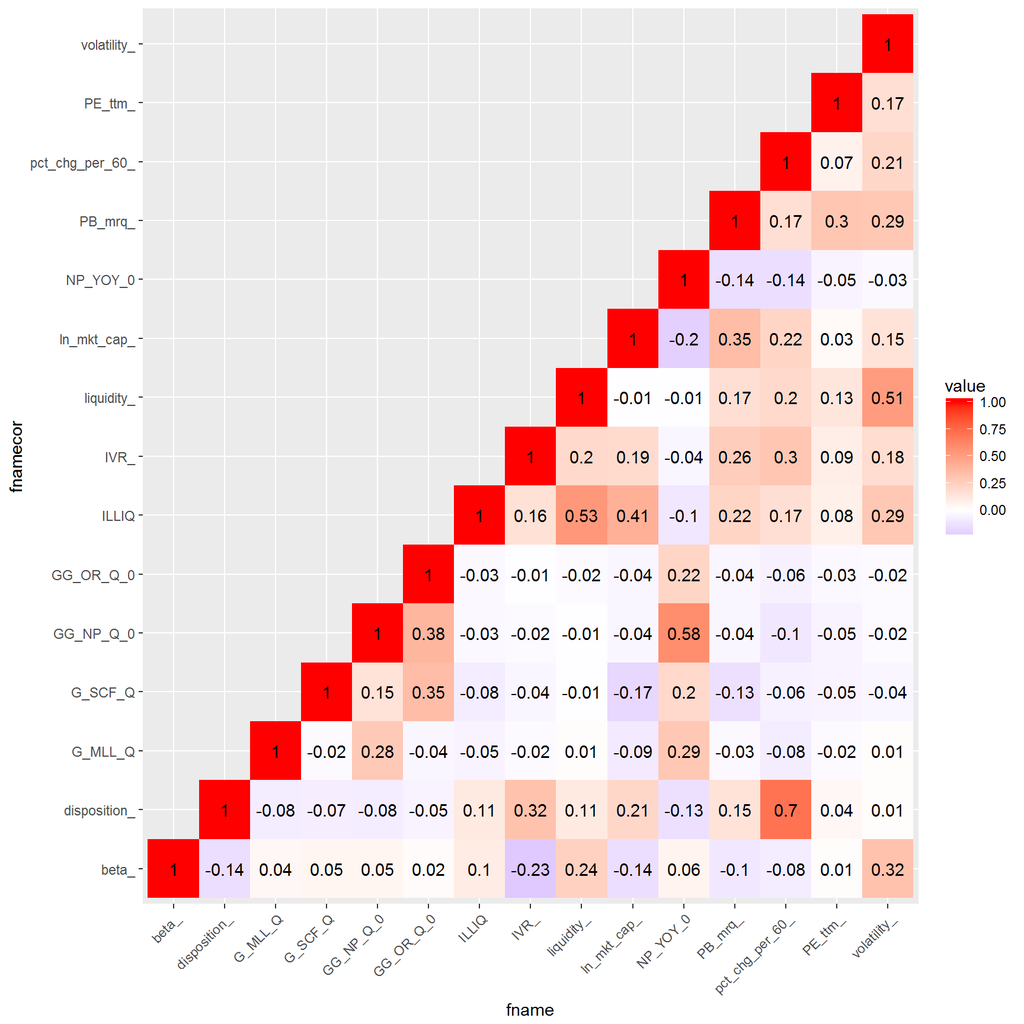

根据上图，我们剔除一些相关性较高的因子,剩下因子每期相关性如下图：

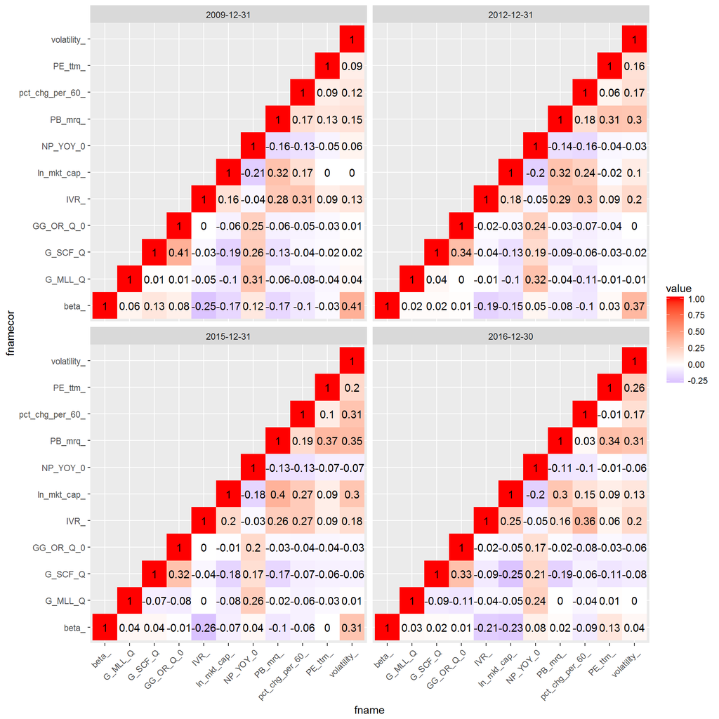

## 三、因子IC

在处理完因子缺失值和因子相关性之后，开始进行因子的有效性检验。

各因子的IC序列如下图所示：

```
## Function getTSR: getting the periodrtn ....
```

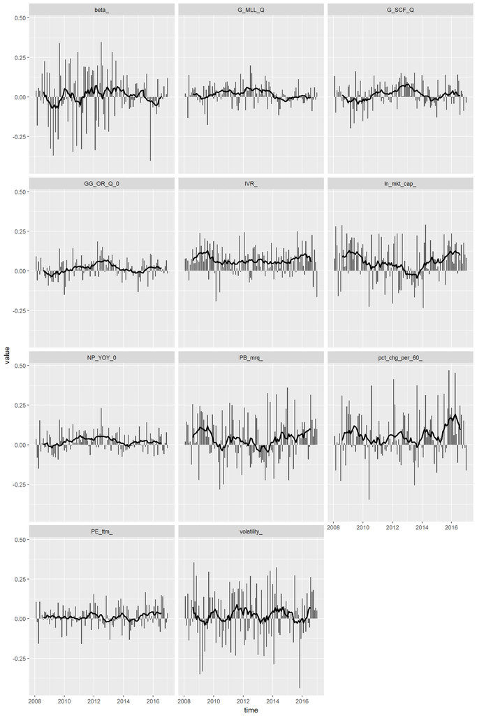

全部因子IC的统计如下表所示：

|  | IC_mean | IC_std | IC_IR | IC_t | IC_p | IC_hitRatio | IC_annu |
| --- | --- | --- | --- | --- | --- | --- | --- |
| IVR_ | 0.07 | 0.09 | 0.77 | 8.03 | 0.00 | 0.76 | 0.23 |
| ln_mkt_cap_ | 0.06 | 0.12 | 0.48 | 5.00 | 0.00 | 0.69 | 0.20 |
| pct_chg_per_60_ | 0.06 | 0.15 | 0.38 | 3.96 | 0.00 | 0.60 | 0.20 |
| PB_mrq_ | 0.04 | 0.14 | 0.29 | 3.00 | 0.00 | 0.60 | 0.14 |
| volatility_ | 0.03 | 0.16 | 0.17 | 1.76 | 0.08 | 0.56 | 0.09 |
| NP_YOY_0 | 0.02 | 0.06 | 0.32 | 3.31 | 0.00 | 0.61 | 0.07 |
| G_MLL_Q | 0.02 | 0.06 | 0.27 | 2.80 | 0.01 | 0.64 | 0.06 |
| GG_OR_Q_0 | 0.02 | 0.06 | 0.25 | 2.57 | 0.01 | 0.61 | 0.05 |
| G_SCF_Q | 0.01 | 0.08 | 0.19 | 1.95 | 0.05 | 0.57 | 0.05 |
| PE_ttm_ | 0.01 | 0.07 | 0.19 | 1.93 | 0.06 | 0.55 | 0.04 |
| beta_ | 0.01 | 0.16 | 0.06 | 0.60 | 0.55 | 0.54 | 0.03 |

综合IC的绝对值、波动率、胜率，选出长期来看有alpha性的因子。alpha因子IC序列如下图所示：

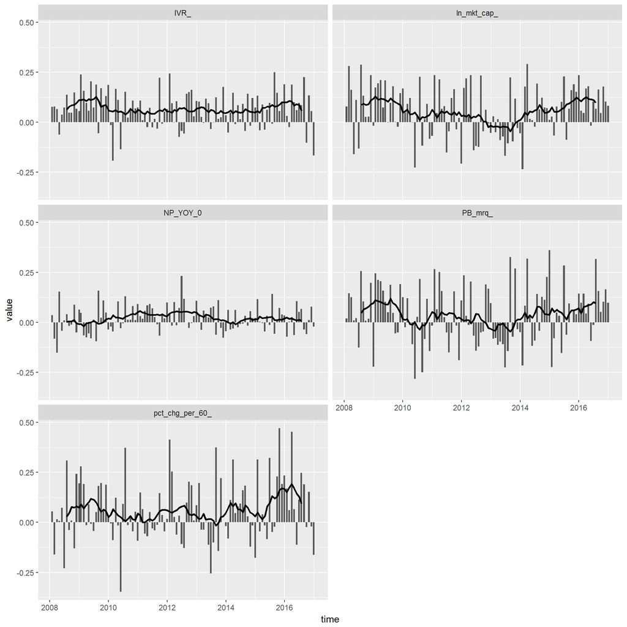

alpha因子分组收益如下图所示：

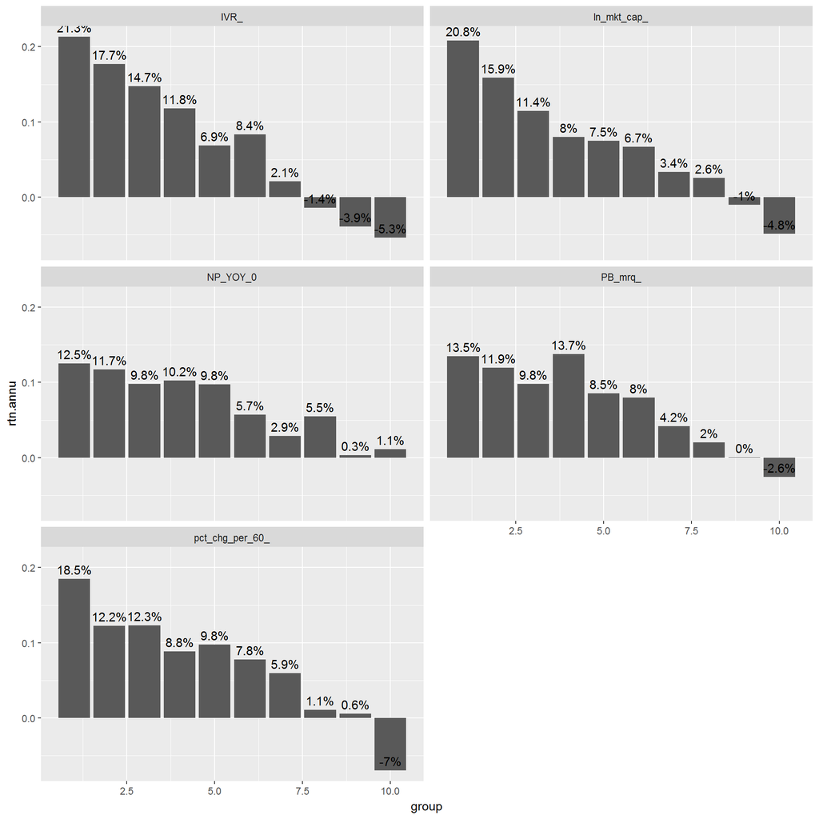

根据因子的IC绝对值和波动率，选出几个风险因子，风险因子IC序列如下图所示：

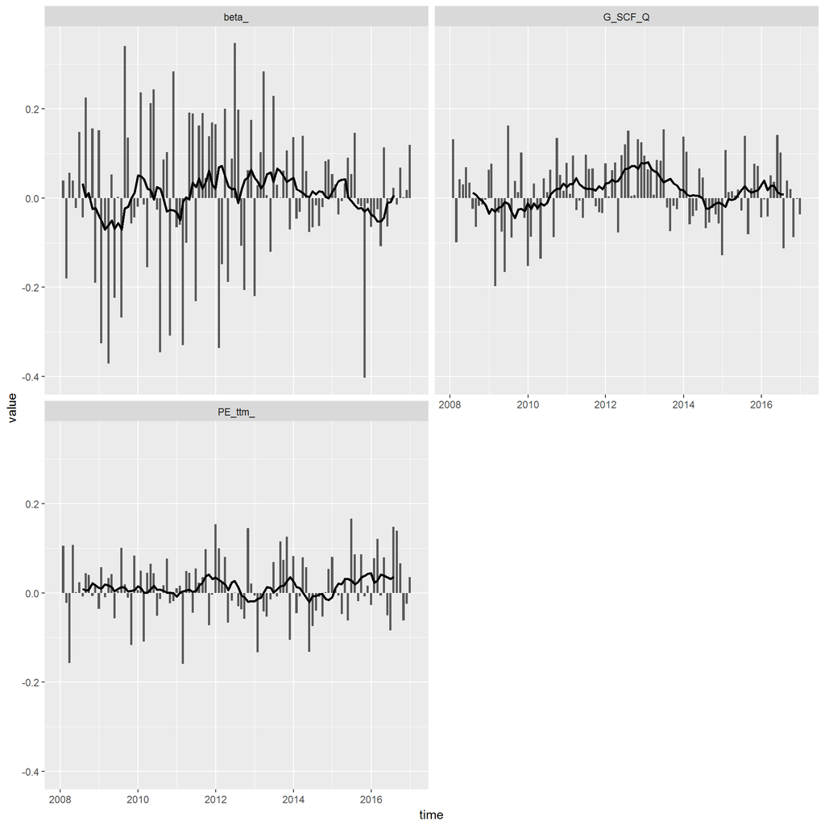

风险因子分组收益如下图所示：

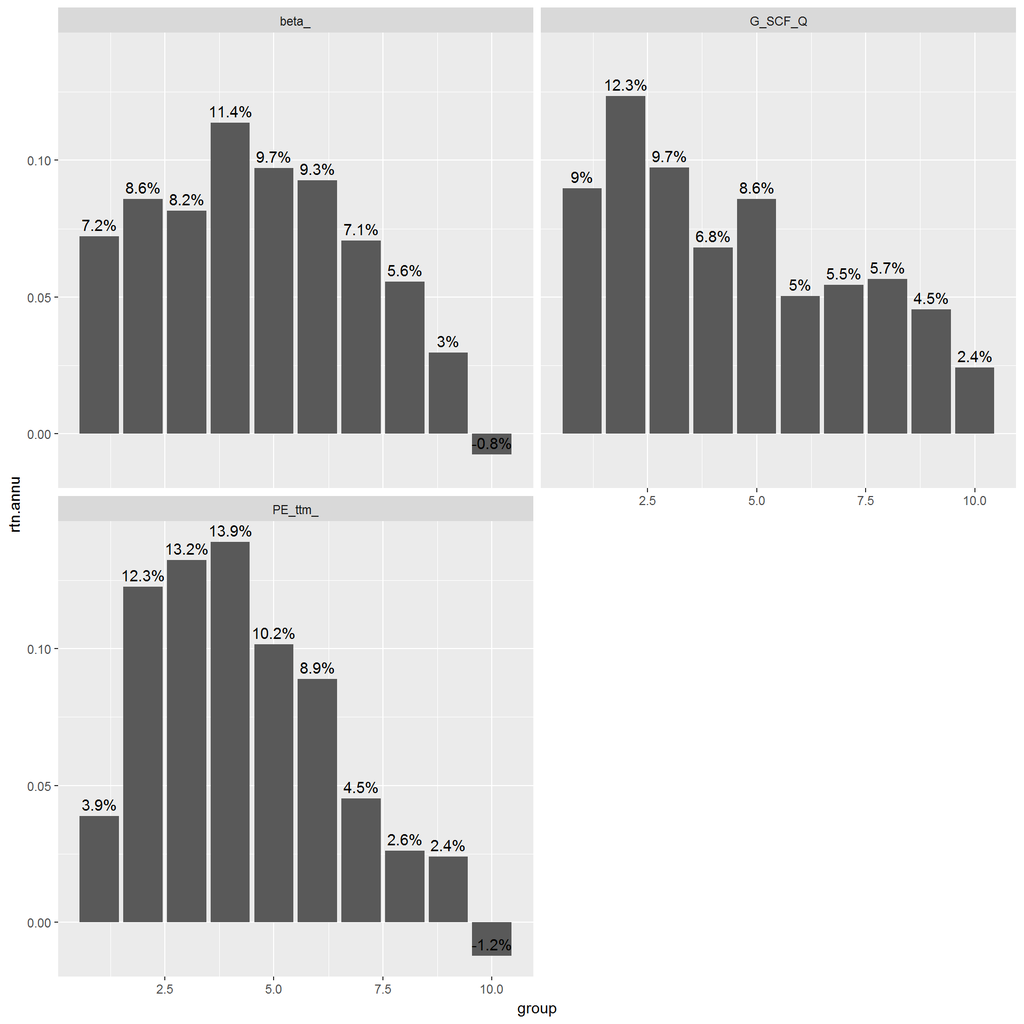

alpha因子和风险因子的IC相关性如下图所示：

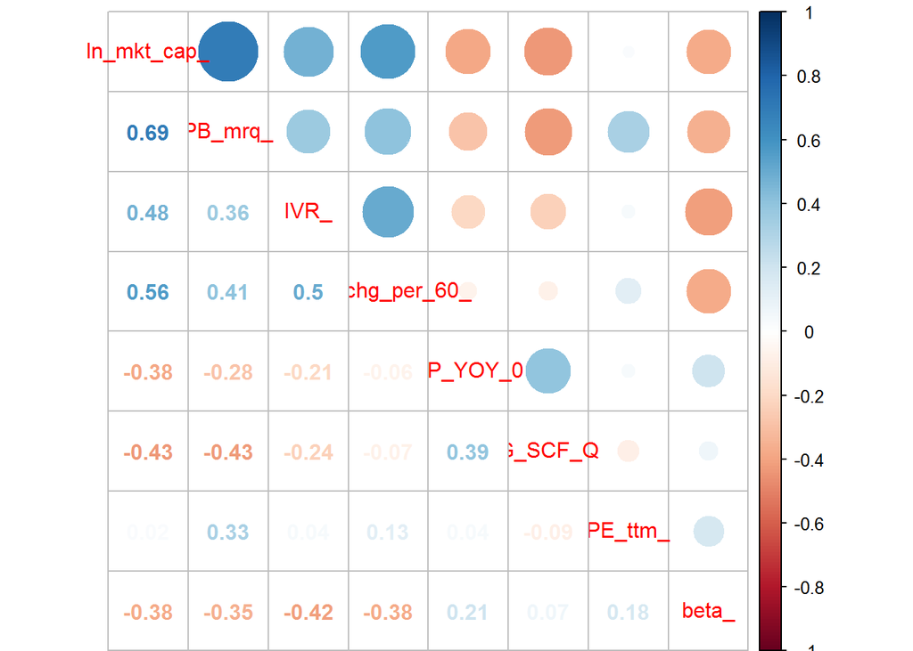

## 四、纯因子收益率Reg

上述因子IC、因子分组是一种检验因子有效性的方法，这种方法不能剥离行业、市值等风格特征。下面构建的纯因子组合是剔除了市值、行业、估值等风险特征的纯因子组合，更能有效的反映因子的alpha性。

在展示纯因子组合收益之前，先展示一下每期回归的$R^2$，如下图所示：

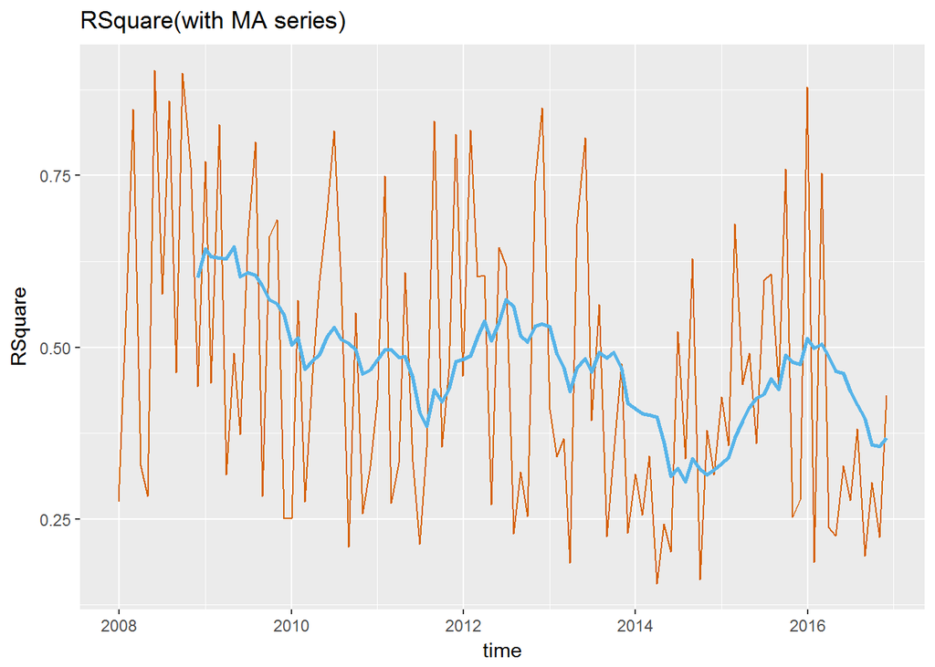

各因子的纯因子组合累积净值曲线如下图所示：

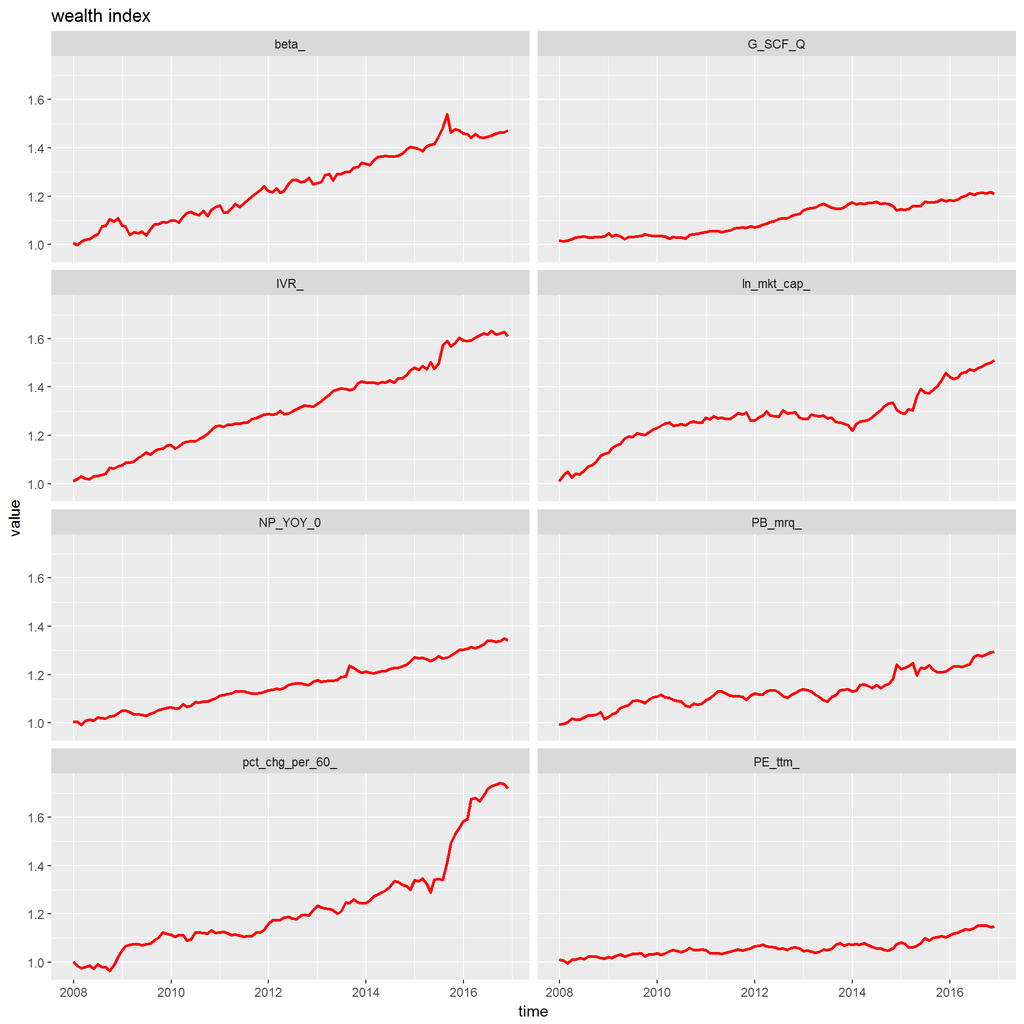

各因子的纯因子组合收益柱状图如下图所示：

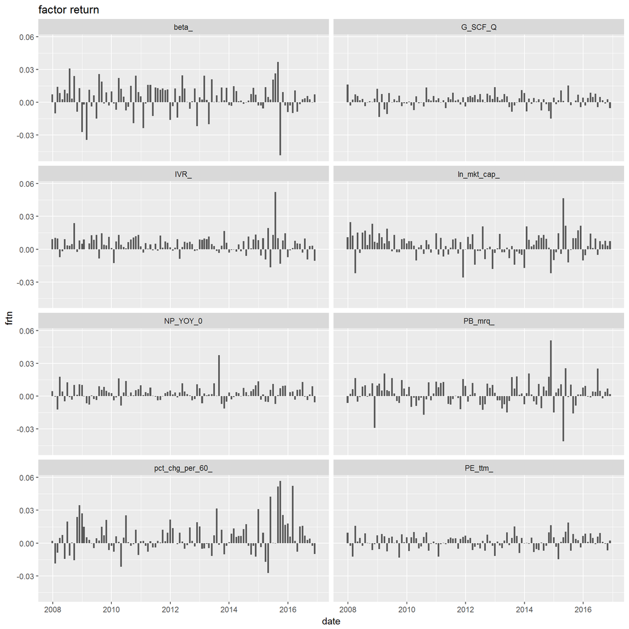

各因子的纯因子组合收益率相关性如下图所示：

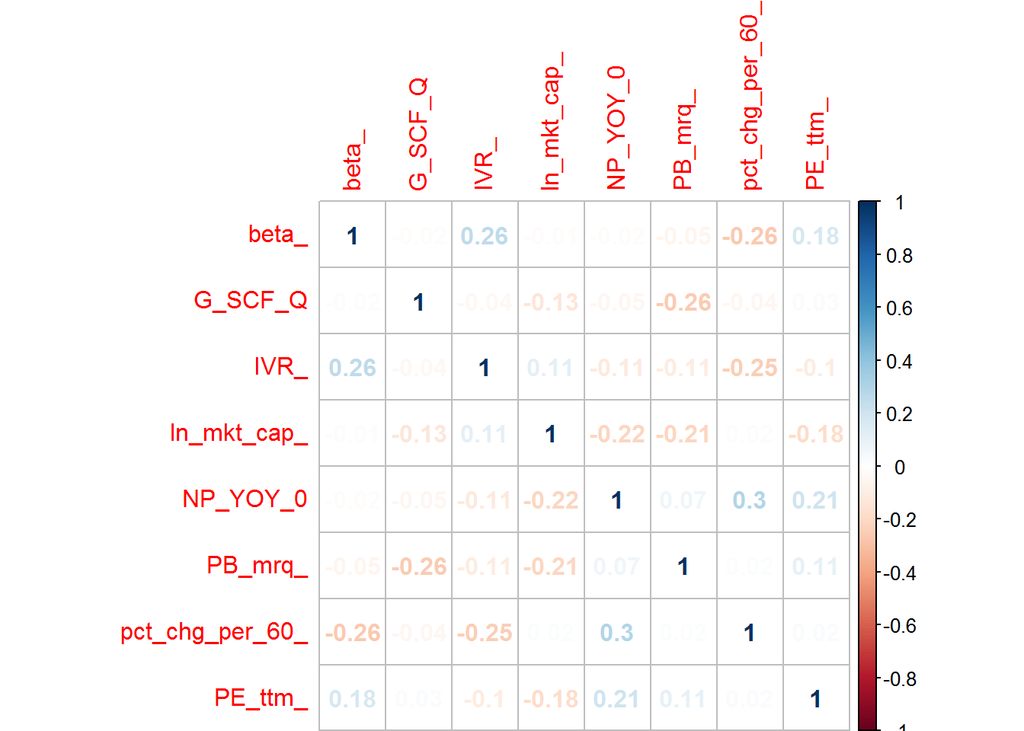

纯因子组合收益率如下图所示：

| fname | Annual Return | Annual StdDev | Sharpe | HitRatio | Worst Drawdown | mean(abs(T)) | percent abs(T)>2 | VIF |
| --- | --- | --- | --- | --- | --- | --- | --- | --- |
| IVR_ | 0.05 | 0.03 | 1.84 | 0.72 | 0.02 | 1.42 | 0.22 | 1.39 |
| NP_YOY_0 | 0.03 | 0.02 | 1.40 | 0.67 | 0.02 | 1.18 | 0.19 | 1.15 |
| ln_mkt_cap_ | 0.05 | 0.04 | 1.24 | 0.65 | 0.06 | 1.74 | 0.39 | 1.47 |
| pct_chg_per_60_ | 0.06 | 0.05 | 1.23 | 0.61 | 0.04 | 2.05 | 0.40 | 1.55 |
| G_SCF_Q | 0.02 | 0.02 | 1.10 | 0.65 | 0.03 | 1.02 | 0.12 | 1.20 |
| beta_ | 0.04 | 0.05 | 0.95 | 0.65 | 0.06 | 2.13 | 0.46 | 1.48 |
| PB_mrq_ | 0.03 | 0.04 | 0.73 | 0.61 | 0.04 | 1.60 | 0.32 | 1.62 |
| PE_ttm_ | 0.02 | 0.02 | 0.68 | 0.59 | 0.03 | 1.19 | 0.19 | 1.15 |